# Statistics for Psychologists 3.

**Computer lab 07**

**Course Number:** BTPS2040BA-E  
**Contact Information:** Please contact me through email anytime: abari.kalman@arts.unideb.hu

Author

Kálmán Abari

Published

March 28, 2025

Learning outcomes

Student will be familiar with file and directory handling.

**To earn 1 point**

To earn 1 point, submit all jamovi OMV files in this Computer lab that contain the activities you completed here. The subject of the email should be `Stat3 - Comp. lab 07`. Send the email to `abari.kurzus@gmail.com`.

Láttuk a feltáró faktorelemzés során a szorongásra vonatkozó példát.

# Worked Example 1

There is a familiar, though not particularly pleasant feeling: anxiety. Everyone has experienced it at some point, although the intensity and circumstances vary widely. Anxiety can arise from many causes—a challenging exam, an operation, an important job interview, and so forth. Sometimes people have “rational” reasons to feel anxious; for example, when facing an important job interview that could influence the next twenty years of their lives, most people experience some degree of tension or anxiety. However, there are individuals who worry about something almost constantly and feel continuous anxiety. To others, this anxiety often seems irrational, since no external circumstances appear to justify the worry (a typical example would be mothers who constantly worry about their children). For such individuals, anxiety becomes a defining aspect of their personality—a personality trait.

In our dataset, we find (hypothetical) data referring to **state and trait anxiety**. The first three items relate to **state anxiety**, while the remaining three items target **trait anxiety**. The survey included the following questions:

- **v1**: I feel restless.
- **v2**: I am worried.
- **v3**: I am afraid that something bad will happen.
- **v4**: I tend to take everything to heart.
- **v5**: I feel like my life is full of difficulties.
- **v6**: I couldn’t imagine a life easier than mine.

Previously, we performed an **Exploratory Factor Analysis (EFA)** on this data. That analysis suggested a clear two-factor structure separating state and trait anxiety, which aligned well with theoretical expectations. It helped us discover underlying relationships in the data without imposing a structure in advance.

Now, we take the next step with **Confirmatory Factor Analysis (CFA)**. Unlike EFA, **CFA is used to test a specific hypothesized structure** based on psychological theory. In our case, we expect:

- **State Anxiety** is measured by items v1, v2, v3.
- **Trait Anxiety** is measured by items v4, v5, v6.

This hypothesized two-factor model can be tested using CFA to see how well it fits the actual data.

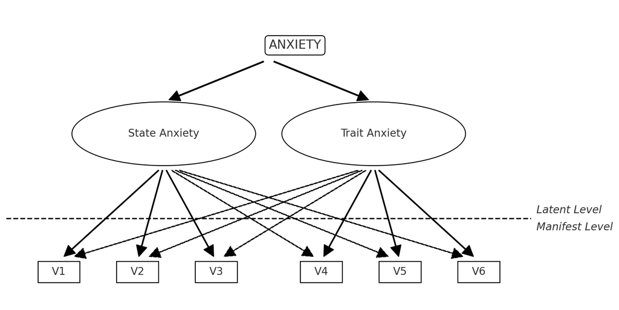

CFA model of state and trait anxiety

CFA helps us answer questions such as:

- Does the data support the idea that anxiety has two distinct but related dimensions?
- Do the items we designed for state and trait anxiety actually measure those constructs?

To evaluate the CFA model, we will examine several **model fit indices**, including:

- **Chi-square test**: Tests whether the model fits the data exactly. A non-significant result suggests a good fit, but this test is sensitive to sample size.
- **RMSEA (Root Mean Square Error of Approximation)**: Values < .06 suggest good fit.
- **CFI (Comparative Fit Index)** and **TLI (Tucker-Lewis Index)**: Values > .95 indicate excellent fit.
- **SRMR (Standardized Root Mean Square Residual)**: Values < .08 are desirable.

CFA is a crucial tool for **validating psychological constructs**. By applying it to the concept of anxiety, we can test whether the state/trait distinction is not only theoretically sound but also empirically supported.

In the following steps, we will demonstrate how to run the CFA, interpret the results, and discuss what they tell us about the structure of anxiety in our dataset.

## Step 1. Import database

Open the `efa_anxiety.xlsx` file in jamovi.

Our database contains the ratings of individuals on state and trait anxiety. The first three items relate to state anxiety, while the remaining three items target trait anxiety: `v1`, `v2`, `v3`, `v4`, `v5`, `v6`.

[figure not shown]

## Step 2. Measure type

Set the measurement level of the variables. All variables are continuous, so we set the measurement level to `Continuous`.

[figure not shown]

## Step 3. Confirmatory Factor Analysis

- Go to the `Analyses` tab and select `Confirmatory Factor Analysis`.
- In the Factors box on the left, click `Add Factor` to add two factors.
- Name the factors `State Anxiety` and `Trait Anxiety`.
- Drag the variables `v1`, `v2`, and `v3` to the `State Anxiety` factor.
- Drag the variables `v4`, `v5`, and `v6` to the `Trait Anxiety` factor.
- In the `Model Fit` box, select the fit indices you want to report. We recommend checking all options.
- In the `Additional Options` box, check Path Diagram to view the model diagram.

[figure not shown]

#### Interpreting the CFA Output in jamovi

The image shows the result of a **Confirmatory Factor Analysis (CFA)** conducted in **jamovi**, based on a dataset measuring **state and trait anxiety** through six observed variables (items v1 to v6).

##### 1. Model Structure (Left Panel)

In the **left panel**, under the “Confirmatory Factor Analysis” module, you can see how the latent variables (factors) are defined:

- **State Anxiety** includes the items:
  - v1: I feel restless
  - v2: I am worried
  - v3: I am afraid that something bad will happen
- **Trait Anxiety** includes:

[output not shown]

Each factor is composed of the variables that theory predicts are related to it. These mappings correspond to our hypothesized two-factor model.

##### 2. Fit Statistics (Top Right)

#### **Test for Exact Fit**

- **Chi-square (χ²)** = 13.9724 with 8 degrees of freedom (df)
- **p-value** = 0.0825

[output not shown]

- **Fit Indices**

[output not shown]

- **Information Criteria**

[output not shown]

##### 3. Path Diagram (Bottom Right)

# Worked Example 2

Almost every psychologist is familiar with the **Big Five personality assessment**. As the name suggests, the Big Five is a **personality model**—and a corresponding assessment method—which assumes that personality is composed of **five independent dimensions**, or **factors**.

Each of these dimensions or factors may have multiple names, but in this study we will use the following labels:

- **Extraversion – Introversion**
- **Agreeableness**
- **Conscientiousness**
- **Emotional Stability – Neuroticism**
- **Openness to Experience**

In this example, we analyze **25 personality psychology items**, which are part of the [**Synthetic Aperture Personality Assessment (SAPA)**](https://www.sapa-project.org/) web-based system.

The items are as follows (items marked with **(R)** are reverse-coded):

- **AGREEAB (Agreeableness):**
  - **AGREEAB_1** – (R) I am indifferent to the feelings of others.
  - **AGREEAB_2** – I am concerned about the well-being of others.
  - **AGREEAB_3** – I know how to comfort others.
  - **AGREEAB_4** – I like children.
  - **AGREEAB_5** – I make people feel at ease.
- **CONSCIE (Conscientiousness):**
  - **CONSCIE_1** – I am exacting in my work.
  - **CONSCIE_2** – I do my work until everything is perfect.
  - **CONSCIE_3** – I do things according to a plan.
  - **CONSCIE_4** – (R) I do things half-heartedly.
  - **CONSCIE_5** – (R) I waste my time.
- **EXTRAVE (Extraversion):**
  - **EXTRAVE_1** – (R) I don’t talk a lot.
  - **EXTRAVE_2** – (R) I find it difficult to approach others.
  - **EXTRAVE_3** – I know how to captivate people.
  - **EXTRAVE_4** – I make friends easily.
  - **EXTRAVE_5** – I take charge.
- **NEUROTI (Neuroticism):**
  - **NEUROTI_1** – I get angry easily.
  - **NEUROTI_2** – I get irritated easily.
  - **NEUROTI_3** – I often have mood swings.
  - **NEUROTI_4** – I often feel sad.
  - **NEUROTI_5** – I panic easily.
- **OPENNES (Openness to Experience):**
  - **OPENNES_1** – I am full of ideas.
  - **OPENNES_2** – (R) I avoid difficult reading material.
  - **OPENNES_3** – I elevate conversations to a higher level.
  - **OPENNES_4** – I take time to reflect and think back on things.
  - **OPENNES_5** – (R) I rarely immerse myself in a specific topic.

Responses were given on a **6-point Likert scale**, where:

1 – Strongly disagree  
2 – Moderately disagree  
3 – Slightly disagree  
4 – Slightly agree  
5 – Moderately agree  
6 – Strongly agree

The responses are included in the `factor_bfi_sample2.xlsx` dataset.

With the help of **Exploratory Factor Analysis (EFA)**, underlying **latent factors** can be easily identified. However, in many cases, we want to see whether a set of **predefined factors** holds up—whether we can **confirm their existence using our data**. This more rigorous testing procedure is called **Confirmatory Factor Analysis (CFA)**. Its purpose is to **confirm a pre-specified latent factor structure** by examining how well the data fit the hypothesized model. The term “confirmatory” refers to the idea that we are testing how strongly the observed data support a **theoretical model** specified in advance.

The main question is: **Do the data support this five-factor structure?** The hypothesized structure is as follows:

- **AGREEAB (Agreeableness):**
  - **AGREEAB_1**
  - **AGREEAB_2**
  - **AGREEAB_3**
  - **AGREEAB_4**
  - **AGREEAB_5**
- **CONSCIE (Conscientiousness):**
  - **CONSCIE_1**
  - **CONSCIE_2**
  - **CONSCIE_3**
  - **CONSCIE_4**
  - **CONSCIE_5**
- **EXTRAVE (Extraversion):**
  - **EXTRAVE_1**
  - **EXTRAVE_2**
  - **EXTRAVE_3**
  - **EXTRAVE_4**
  - **EXTRAVE_5**
- **NEUROTI (Neuroticism):**
  - **NEUROTI_1**
  - **NEUROTI_2**
  - **NEUROTI_3**
  - **NEUROTI_4**
  - **NEUROTI_5**
- **OPENNES (Openness to Experience):**
  - **OPENNES_1**
  - **OPENNES_2**
  - **OPENNES_3**
  - **OPENNES_4**
  - **OPENNES_5**

## Step 1. Import database

Open the `factor_bfi_sample2.xlsx` file in jamovi.

Our database contains the ratings of individuals on the Big Five personality assessment. The items are grouped into five factors: `AGREEAB`, `CONSCIE`, `EXTRAVE`, `NEUROTI`, and `OPENNES`.

[figure not shown]

## Step 2. Measure type

Set the measurement level of the variables. All variables are continuous, so we set the measurement level to `Continuous`.

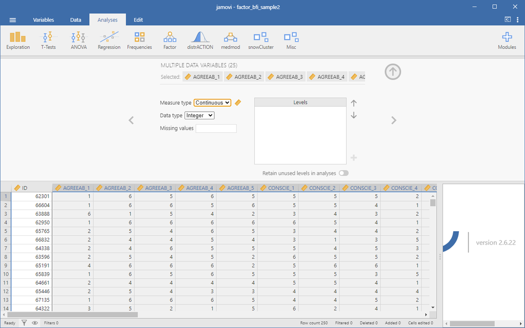

## Step 3. Confirmatory Factor Analysis

- Go to the `Analyses` tab and select `Confirmatory Factor Analysis`.
- In the Factors box on the left, click `Add Factor` to add five factors.
- Name the factors `AGREEAB`, `CONSCIE`, `EXTRAVE`, `NEUROTI`, and `OPENNES`.
- Drag the variables to their respective factors based on the hypothesized structure.
  - Drag the vaiable `AGREEAB_1`, `AGREEAB_2`, `AGREEAB_3`, `AGREEAB_4`, and `AGREEAB_5` to the `AGREEAB` factor.
  - Drag the vaiable `CONSCIE_1`, `CONSCIE_2`, `CONSCIE_3`, `CONSCIE_4`, and `CONSCIE_5` to the `CONSCIE` factor.
  - Drag the vaiable `EXTRAVE_1`, `EXTRAVE_2`, `EXTRAVE_3`, `EXTRAVE_4`, and `EXTRAVE_5` to the `EXTRAVE` factor.
  - Drag the vaiable `NEUROTI_1`, `NEUROTI_2`, `NEUROTI_3`, `NEUROTI_4`, and `NEUROTI_5` to the `NEUROTI` factor.
  - Drag the vaiable `OPENNES_1`, `OPENNES_2`, `OPENNES_3`, `OPENNES_4`, and `OPENNES_5` to the `OPENNES` factor.
- In the `Model Fit` box, select the fit indices you want to report. We recommend checking all options.
- In the `Additional Options` box, check Path Diagram to view the model diagram.

[figure not shown]

#### Interpreting the CFA Output for the Big Five Model in jamovi

This image presents the results of a **Confirmatory Factor Analysis (CFA)** conducted on a dataset designed to measure the **Big Five personality traits** using 25 items. These items were grouped into five factors according to the theoretical model:

- **AGREEAB** (Agreeableness)
- **CONSCIE** (Conscientiousness)
- **EXTRAVE** (Extraversion)
- **NEUROTI** (Neuroticism)
- **OPENNES** (Openness to Experience)

##### 1. Model Setup (Left Panel)

In the left panel, we can see that the user has:

- Loaded the variables from the `factor_bfi_sample2.xlsx` dataset.
- Assigned five items to each of the five latent factors using the “Factors” section.
- Enabled the key model fit indices and the path diagram.

This reflects the theoretical assumption that the 25 personality items should load onto five corresponding latent variables, each representing one of the Big Five traits.

##### 2. Model Fit Statistics (Top Right)

#### **Chi-square Test of Model Fit**

- **χ² = 739.73**
- **df = 265**
- **p < .0001**

The significant chi-square indicates that the model does not perfectly reproduce the observed covariance matrix. However, since chi-square is sensitive to sample size, we need to rely more heavily on the additional fit indices.

#### **Fit Indices**

- **CFI (Comparative Fit Index): 0.7624**
- **TLI (Tucker-Lewis Index): 0.7310**
- **SRMR (Standardized Root Mean Square Residual): 0.0897**
- **RMSEA (Root Mean Square Error of Approximation): 0.0847**

[output not shown]

**Interpretation:**

- CFI and TLI values **below 0.90** suggest a **poor fit** to the data.
- SRMR is **close to acceptable** (< 0.08 preferred), but still slightly high.
- RMSEA is **above the commonly accepted threshold** of 0.06, indicating **mediocre to poor fit**.

#### **Information Criteria**

- **AIC = 20749.72**
- **BIC = 21049.04**
  - These can be used for comparing alternative models; lower values indicate better fit.

##### 3. Path Diagram (Bottom Right)

The path diagram visualizes the CFA model:

- Latent variables (AGREEAB, CONSCIE, EXTRAVE, NEUROTI, OPENNES) are shown as **circles**
- Observed variables (the 25 items) are represented by **squares**.
- Arrows from latent variables to observed variables represent the hypothesized loadings.
- **Curved arrows** between latent variables indicate that the five personality factors are **allowed to correlate**.

This structure reflects the theoretical Big Five model, where each observed item is associated with one and only one latent trait, and all latent traits are correlated.

##### 4. Overall Conclusion

- The five-factor model was **correctly specified** based on theory and loaded in jamovi.
- The model shows **partial support** in the data, but fit indices suggest room for improvement:
  - The model does **not fit the data well** according to conventional cutoff values.
  - This may suggest issues such as:
    - Some items not fitting well with their assigned factors.
    - Overlap or redundancy between some items.
    - The need for model refinement (e.g., correlated residuals, dropping problematic items).

## Step 4. Exploratory Factor Analysis

Try to find an explanation for the poor model fit. EFA can help identify problematic items.

- Go to the `Analyses` tab and select `Exploratory Factor Analysis`.
- Drag all 25 items to the `Variables` box.

[figure not shown]

After performing a CFA, an **Exploratory Factor Analysis (EFA)** was conducted to further examine the underlying structure of the 25 personality items.

- Some factors (e.g., Openness or Agreeableness) may include items with **high uniqueness values**, indicating they are not well-explained by the latent factors.

**Summary and Recommendations**

- The theoretical five-factor structure is only **partially supported** in this dataset.
- EFA revealed that some items do not align well with their intended factors, which may account for the CFA’s poor fit.
- **Next steps:**
  - Reevaluate item wording, especially reverse-coded items.
  - Consider removing or reassigning items with weak or cross-loadings.
  - Rerun CFA after refining the measurement model.
  - By refining the model based on EFA insights, a better-fitting CFA model can be achieved, leading to a more valid representation of the Big Five structure.